# Bonus 1: Numerical Optimization for Logistic Regression.

### Name: [Lijin Zhou]

## 0. You will do the following:

1. Read the lecture note: [click here](https://github.com/wangshusen/DeepLearning/blob/master/LectureNotes/Logistic/paper/logistic.pdf)
2. Read, complete, and run my code.
3. **Implement mini-batch SGD** and evaluate the performance. (1 bonus point.)
4. Convert the .IPYNB file to .HTML file.
   - The HTML file must contain **the code** and **the output after execution**.
5. Upload this .HTML file to your Github repo.
6. Submit the link to this .HTML file to Canvas.
   - Example: https://github.com/wangshusen/CS583-2019F/blob/master/homework/Bonus1/Bonus1.html

## Grading criteria:

1. When computing the `gradient` and `objective function value` using a batch of samples, use **matrix-vector multiplication** rather than a FOR LOOP of **vector-vector multiplications**.
2. Plot `objective function value` against `epochs`. In the plot, compare GD, SGD, and MB-SGD (with $b=8$ and $b=64$). The plot must look reasonable.

# 1. Data processing

- Download the Diabete dataset from https://www.csie.ntu.edu.tw/~cjlin/libsvmtools/datasets/binary/diabetes
- Load the data using sklearn.
- Preprocess the data.

## 1.1. Load the data

```python
from sklearn import datasets
import numpy

x_sparse, y = datasets.load_svmlight_file('diabetes')
x = x_sparse.todense()

print('Shape of x: ' + str(x.shape))
print('Shape of y: ' + str(y.shape))
```

```
Shape of x: (768, 8)
Shape of y: (768,)
```

## 1.2. Partition to training and test sets

```python
# partition the data to training and test sets
n = x.shape[0]
n_train = int(numpy.ceil(n * 0.8))
n_test = n - n_train

rand_indices = numpy.random.permutation(n)
train_indices = rand_indices[0:n_train]
test_indices = rand_indices[n_train:n]

x_train = x[train_indices, :]
x_test = x[test_indices, :]
y_train = y[train_indices].reshape(n_train, 1)
y_test = y[test_indices].reshape(n_test, 1)

print('Shape of x_train: ' + str(x_train.shape))
print('Shape of x_test: ' + str(x_test.shape))
print('Shape of y_train: ' + str(y_train.shape))
print('Shape of y_test: ' + str(y_test.shape))
```

```
Shape of x_train: (615, 8)
Shape of x_test: (153, 8)
Shape of y_train: (615, 1)
Shape of y_test: (153, 1)
```

## 1.3. Feature scaling

Use the standardization to trainsform both training and test features

```python
# Standardization
import numpy
import math

# calculate mu and sig using the training set
d = x_train.shape[1]
mu = numpy.mean(x_train, axis=0).reshape(1, d)
sig = numpy.std(x_train, axis=0).reshape(1, d)

# transform the training features
x_train = (x_train - mu) / (sig + 1E-6)

# transform the test features
x_test = (x_test - mu) / (sig + 1E-6)

print('test mean = ')
print(numpy.mean(x_test, axis=0))

print('test std = ')
print(numpy.std(x_test, axis=0))
```

```
test mean =
[[ 0.12807054  0.00844432  0.10286766  0.19849607  0.05649189 -0.02655328
  -0.07565998 -0.05853927]]
test std =
[[0.9087111  0.98785863 0.7272678  0.9546708  1.00782291 0.95390034
  0.70508671 0.83982855]]
```

## 1.4. Add a dimension of all ones

```python
n_train, d = x_train.shape
x_train = numpy.concatenate((x_train, numpy.ones((n_train, 1))), axis=1)

n_test, d = x_test.shape
x_test = numpy.concatenate((x_test, numpy.ones((n_test, 1))), axis=1)

print('Shape of x_train: ' + str(x_train.shape))
print('Shape of x_test: ' + str(x_test.shape))
```

```
Shape of x_train: (615, 9)
Shape of x_test: (153, 9)
```

# 2. Logistic regression model

The objective function is $Q (w; X, y) = \frac{1}{n} \sum_{i=1}^n \log \Big( 1 + \exp \big( - y_i x_i^T w \big) \Big) + \frac{\lambda}{2} \| w \|_2^2 $.

```python
# Calculate the objective function value
# Inputs:
#     w: d-by-1 matrix
#     x: n-by-d matrix
#     y: n-by-1 matrix
#     lam: scalar, the regularization parameter
# Return:
#     objective function value (scalar)
def objective(w, x, y, lam):
    n, d = x.shape
    yx = numpy.multiply(y, x) # n-by-d matrix
    yxw = numpy.dot(yx, w) # n-by-1 matrix
    vec1 = numpy.exp(-yxw) # n-by-1 matrix
    vec2 = numpy.log(1 + vec1) # n-by-1 matrix
    loss = numpy.mean(vec2) # scalar
    reg = lam / 2 * numpy.sum(w * w) # scalar
    return loss + reg
```

```python
# initialize w
d = x_train.shape[1]
w = numpy.zeros((d, 1))

# evaluate the objective function value at w
lam = 1E-6
objval0 = objective(w, x_train, y_train, lam)
print('Initial objective function value = ' + str(objval0))
```

```
Initial objective function value = 0.6931471805599453
```

# 3. Numerical optimization

## 3.1. Gradient descent

The gradient at $w$ is $g = - \frac{1}{n} \sum_{i=1}^n \frac{y_i x_i }{1 + \exp ( y_i x_i^T w)} + \lambda w$

```python
# Calculate the gradient
# Inputs:
#     w: d-by-1 matrix
#     x: n-by-d matrix
#     y: n-by-1 matrix
#     lam: scalar, the regularization parameter
# Return:
#     g: g: d-by-1 matrix, full gradient
def gradient(w, x, y, lam):
    n, d = x.shape
    yx = numpy.multiply(y, x) # n-by-d matrix
    yxw = numpy.dot(yx, w) # n-by-1 matrix
    vec1 = numpy.exp(yxw) # n-by-1 matrix
    vec2 = numpy.divide(yx, 1+vec1) # n-by-d matrix
    vec3 = -numpy.mean(vec2, axis=0).reshape(d, 1) # d-by-1 matrix
    g = vec3 + lam * w
    return g
```

```python
# Gradient descent for solving logistic regression
# Inputs:
#     x: n-by-d matrix
#     y: n-by-1 matrix
#     lam: scalar, the regularization parameter
#     stepsize: scalar
#     max_iter: integer, the maximal iterations
#     w: d-by-1 matrix, initialization of w
# Return:
#     w: d-by-1 matrix, the solution
#     objvals: a record of each iteration's objective value
def grad_descent(x, y, lam, stepsize, max_iter=100, w=None):
    n, d = x.shape
    objvals = numpy.zeros(max_iter) # store the objective values
    if w is None:
        w = numpy.zeros((d, 1)) # zero initialization

    for t in range(max_iter):
        objval = objective(w, x, y, lam)
        objvals[t] = objval
        print('Objective value at t=' + str(t) + ' is ' + str(objval))
        g = gradient(w, x, y, lam)
        w -= stepsize * g

    return w, objvals
```

Run gradient descent.

```python
lam = 1E-6
stepsize = 1.0
w, objvals_gd = grad_descent(x_train, y_train, lam, stepsize)
```

```
Objective value at t=0 is 0.6931471805599453
Objective value at t=1 is 0.5864094999072543
Objective value at t=2 is 0.5412341038663694
Objective value at t=3 is 0.5165506952986976
Objective value at t=4 is 0.50106523117745
Objective value at t=5 is 0.49057449676607817
Objective value at t=6 is 0.4831173250220645
Objective value at t=7 is 0.477637309836588
Objective value at t=8 is 0.4735093088277256
Objective value at t=9 is 0.4703387689845363
Objective value at t=10 is 0.46786483027974374
Objective value at t=11 is 0.46590883785262693
Objective value at t=12 is 0.4643449670621648
Objective value at t=13 is 0.4630825387750398
Objective value at t=14 is 0.46205491892718475
Objective value at t=15 is 0.4612123143918002
Objective value at t=16 is 0.46051696696391026
Objective value at t=17 is 0.4599398714104389
Objective value at t=18 is 0.4594584884136023
Objective value at t=19 is 0.4590551220555774
Objective value at t=20 is 0.45871575019045935
Objective value at t=21 is 0.4584291690233153
Objective value at t=22 is 0.45818635921817774
Objective value at t=23 is 0.45798001049595005
Objective value at t=24 is 0.45780416115232514
Objective value at t=25 is 0.4576539219385421
Objective value at t=26 is 0.4575252625836005
Objective value at t=27 is 0.45741484532370885
Objective value at t=28 is 0.4573198940548598
Objective value at t=29 is 0.45723809072905713
Objective value at t=30 is 0.4571674927637195
Objective value at t=31 is 0.45710646678760364
Objective value at t=32 is 0.45705363518164227
Objective value at t=33 is 0.45700783271023554
Objective value at t=34 is 0.4569680711615963
Objective value at t=35 is 0.45693351038344593
Objective value at t=36 is 0.4569034344542989
Objective value at t=37 is 0.45687723200046093
Objective value at t=38 is 0.45685437987616967
Objective value at t=39 is 0.45683442958462045
```

[output cut: 45 more lines]

```
Objective value at t=85 is 0.4566909781496225
Objective value at t=86 is 0.45669091570821474
Objective value at t=87 is 0.45669086009514154
Objective value at t=88 is 0.4566908105569428
Objective value at t=89 is 0.4566907664242586
Objective value at t=90 is 0.45669072710230624
Objective value at t=91 is 0.45669069206245294
Objective value at t=92 is 0.456690660834759
Objective value at t=93 is 0.4566906330013748
Objective value at t=94 is 0.45669060819069396
Objective value at t=95 is 0.4566905860721716
Objective value at t=96 is 0.4566905663517345
Objective value at t=97 is 0.45669054876770954
Objective value at t=98 is 0.4566905330872152
Objective value at t=99 is 0.456690519102959
```

## 3.2. Stochastic gradient descent (SGD)

Define $Q_i (w) = \log \Big( 1 + \exp \big( - y_i x_i^T w \big) \Big) + \frac{\lambda}{2} \| w \|_2^2 $.

The stochastic gradient at $w$ is $g_i = \frac{\partial Q_i }{ \partial w} = -\frac{y_i x_i }{1 + \exp ( y_i x_i^T w)} + \lambda w$.

```python
# Calculate the objective Q_i and the gradient of Q_i
# Inputs:
#     w: d-by-1 matrix
#     xi: 1-by-d matrix
#     yi: scalar
#     lam: scalar, the regularization parameter
# Return:
#     obj: scalar, the objective Q_i
#     g: d-by-1 matrix, gradient of Q_i
def stochastic_objective_gradient(w, xi, yi, lam):
    d = xi.shape[0]
    yx = yi * xi # 1-by-d matrix
    yxw = float(numpy.dot(yx, w)) # scalar

    # calculate objective function Q_i
    loss = numpy.log(1 + numpy.exp(-yxw)) # scalar
    reg = lam / 2 * numpy.sum(w * w) # scalar
    obj = loss + reg

    # calculate stochastic gradient
    g_loss = -yx.T / (1 + numpy.exp(yxw)) # d-by-1 matrix
    g = g_loss + lam * w # d-by-1 matrix

    return obj, g
```

```python
# SGD for solving logistic regression
# Inputs:
#     x: n-by-d matrix
#     y: n-by-1 matrix
#     lam: scalar, the regularization parameter
#     stepsize: scalar
#     max_epoch: integer, the maximal epochs
#     w: d-by-1 matrix, initialization of w
# Return:
#     w: the solution
#     objvals: record of each iteration's objective value
def sgd(x, y, lam, stepsize, max_epoch=100, w=None):
    n, d = x.shape
    objvals = numpy.zeros(max_epoch) # store the objective values
    if w is None:
        w = numpy.zeros((d, 1)) # zero initialization

    for t in range(max_epoch):
        # randomly shuffle the samples
        rand_indices = numpy.random.permutation(n)
        x_rand = x[rand_indices, :]
        y_rand = y[rand_indices, :]
        objval = 0 # accumulate the objective values
        for i in range(n):
            xi = x_rand[i, :] # 1-by-d matrix
            yi = float(y_rand[i, :])# scalar
            obj, g = stochastic_objective_gradient(w, xi, yi, lam)
            objval += obj
            w -= stepsize * g

        stepsize *= 0.9 # decrease step size
        objval /= n
        objvals[t] = objval
        print('Objective value at epoch t=' + str(t) + ' is ' + str(objval))

    return w, objvals
```

Run SGD.

```python
lam = 1E-6
stepsize = 0.1
w, objvals_sgd = sgd(x_train, y_train, lam, stepsize)
```

```
Objective value at epoch t=0 is 0.5196314673728702
Objective value at epoch t=1 is 0.5100900214362637
Objective value at epoch t=2 is 0.49648560849210893
Objective value at epoch t=3 is 0.4817594969736712
Objective value at epoch t=4 is 0.4927616678537361
Objective value at epoch t=5 is 0.4899715879134285
Objective value at epoch t=6 is 0.48808851308926526
Objective value at epoch t=7 is 0.4834306653595434
Objective value at epoch t=8 is 0.4788829601861163
Objective value at epoch t=9 is 0.4771634866823421
Objective value at epoch t=10 is 0.47677561070959856
Objective value at epoch t=11 is 0.47383747431457374
Objective value at epoch t=12 is 0.4726633048011961
Objective value at epoch t=13 is 0.47171357903729877
Objective value at epoch t=14 is 0.47030445010155436
Objective value at epoch t=15 is 0.46684698516017176
Objective value at epoch t=16 is 0.46967333913730525
Objective value at epoch t=17 is 0.4647524834219442
Objective value at epoch t=18 is 0.46595128589299506
Objective value at epoch t=19 is 0.46602121893702864
Objective value at epoch t=20 is 0.4639000297322583
Objective value at epoch t=21 is 0.46249498058049365
Objective value at epoch t=22 is 0.46325512665277824
Objective value at epoch t=23 is 0.462698870496796
Objective value at epoch t=24 is 0.4619868028061211
Objective value at epoch t=25 is 0.4616468370600411
Objective value at epoch t=26 is 0.4608708918079474
Objective value at epoch t=27 is 0.46052797011476626
Objective value at epoch t=28 is 0.4601998213057731
Objective value at epoch t=29 is 0.46010864373156
Objective value at epoch t=30 is 0.45971791393796985
Objective value at epoch t=31 is 0.45935578681656075
Objective value at epoch t=32 is 0.4590948784459519
Objective value at epoch t=33 is 0.4588634860380336
Objective value at epoch t=34 is 0.4587368721917858
Objective value at epoch t=35 is 0.45845252116722496
Objective value at epoch t=36 is 0.4582286189724914
Objective value at epoch t=37 is 0.4581249499500477
Objective value at epoch t=38 is 0.45793838808164333
Objective value at epoch t=39 is 0.4578719985819705
```

[output cut: 45 more lines]

```
Objective value at epoch t=85 is 0.45670017446019767
Objective value at epoch t=86 is 0.4566992272623273
Objective value at epoch t=87 is 0.4566983696418187
Objective value at epoch t=88 is 0.4566976033551877
Objective value at epoch t=89 is 0.45669691042492383
Objective value at epoch t=90 is 0.4566962883718302
Objective value at epoch t=91 is 0.45669572710455925
Objective value at epoch t=92 is 0.4566952225929677
Objective value at epoch t=93 is 0.45669476858115227
Objective value at epoch t=94 is 0.45669435968313904
Objective value at epoch t=95 is 0.4566939920192282
Objective value at epoch t=96 is 0.45669366074674117
Objective value at epoch t=97 is 0.45669336285613243
Objective value at epoch t=98 is 0.4566930946713552
Objective value at epoch t=99 is 0.4566928532655017
```

# 4. Compare GD with SGD

Plot objective function values against epochs.

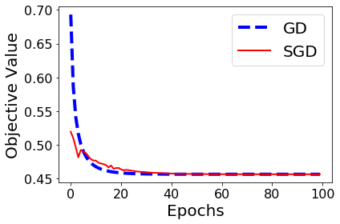

```python
import matplotlib.pyplot as plt
%matplotlib inline

fig = plt.figure(figsize=(6, 4))

epochs_gd = range(len(objvals_gd))
epochs_sgd = range(len(objvals_sgd))

line0, = plt.plot(epochs_gd, objvals_gd, '--b', LineWidth=4)
line1, = plt.plot(epochs_sgd, objvals_sgd, '-r', LineWidth=2)
plt.xlabel('Epochs', FontSize=20)
plt.ylabel('Objective Value', FontSize=20)
plt.xticks(FontSize=16)
plt.yticks(FontSize=16)
plt.legend([line0, line1], ['GD', 'SGD'], fontsize=20)
plt.tight_layout()
plt.show()
fig.savefig('compare_gd_sgd.pdf', format='pdf', dpi=1200)
```

# 5. Prediction

```python
# Predict class label
# Inputs:
#     w: d-by-1 matrix
#     X: m-by-d matrix
# Return:
#     f: m-by-1 matrix, the predictions
def predict(w, X):
    xw = numpy.dot(X, w)
    f = numpy.sign(xw)
    return f
```

```python
# evaluate training error
f_train = predict(w, x_train)
diff = numpy.abs(f_train - y_train) / 2
error_train = numpy.mean(diff)
print('Training classification error is ' + str(error_train))
```

```
Training classification error is 0.2048780487804878
```

```python
# evaluate test error
f_test = predict(w, x_test)
diff = numpy.abs(f_test - y_test) / 2
error_test = numpy.mean(diff)
print('Test classification error is ' + str(error_test))
```

```
Test classification error is 0.24836601307189543
```

# 6. Mini-batch SGD (fill the code)

Define $Q_I (w) = \frac{1}{b} \sum_{i \in I} \log \Big( 1 + \exp \big( - y_i x_i^T w \big) \Big) + \frac{\lambda}{2} \| w \|_2^2 $, where $I$ is a set containing $b$ indices randomly drawn from $\{ 1, \cdots , n \}$ without replacement.

The stochastic gradient at $w$ is $g_I = \frac{\partial Q_I }{ \partial w} = \frac{1}{b} \sum_{i \in I} \frac{- y_i x_i }{1 + \exp ( y_i x_i^T w)} + \lambda w$.

## 6.1. Compute the objective $Q_I$ and its gradient using a batch of samples

```python
# Calculate the objective Q_I and the gradient of Q_I
# Inputs:
#     w: d-by-1 matrix
#     xi: 1-by-d matrix
#     yi: scalar
#     lam: scalar, the regularization parameter
#     b: integer, the batch size
# Return:
#     obj: scalar, the objective Q_i
#     g: d-by-1 matrix, gradient of Q_i
def mb_stochastic_objective_gradient(w, xi, yi, lam, b):
    # Fill the function
    # Follow the implementation of stochastic_objective_gradient
    # Use matrix-vector multiplication; do not use FOR LOOP of vector-vector multiplications
    d = xi.shape[0]
    yx = yi * xi # 1-by-d matrix
    yxw = float(numpy.dot(yx, w)) # scalar


    # calculate objective function Q_i
    loss = numpy.log(1 + numpy.exp(-yxw))# scalar
    reg = lam / 2 * numpy.sum(w * w) # scalar
    obj = loss + reg

    # calculate stochastic gradient
    g_loss = -yx.T / (1 + numpy.exp(yxw)) # d-by-1 matrix
    g = g_loss + lam * w # d-by-1 matrix

    return obj, g
```

## 6.2. Implement mini-batch SGD

```python
# Mini-Batch SGD for solving logistic regression
# Inputs:
#     x: n-by-d matrix
#     y: n-by-1 matrix
#     lam: scalar, the regularization parameter
#     b: integer, the batch size
#     stepsize: scalar
#     max_epoch: integer, the maximal epochs
#     w: d-by-1 matrix, initialization of w
# Return:
#     w: the solution
#     objvals: record of each iteration's objective value
def mb_sgd(x, y, lam, b, stepsize, max_epoch=100, w=None):
    # Fill the function
    # Follow the implementation of sgd
    # Record one objective value per epoch (not per iteration!)

    n, d = x.shape
    objvals = numpy.zeros(max_epoch) # store the objective values
    x_mini = []
    y_mini = []
    if w is None:
        w = numpy.zeros((d, 1)) # zero initialization

    for t in range(max_epoch):
        # randomly shuffle the samples
        rand_indices = numpy.random.permutation(n)
        x_rand = x[rand_indices, :]
        y_rand = y[rand_indices, :]
        objval = 0 # accumulate the objective values
        for i in range(0,n,b):
            x_mini = x_rand[i:i+b,:]
            y_mini = y_rand[i:i+b,:]
            for xi, yi in zip(x_mini, y_mini):
                    obj, g = mb_stochastic_objective_gradient(w, xi, yi, lam, b)
                    objval += obj
                    w -= stepsize * g

        stepsize *= 0.9 # decrease step size
        objval /= n
        objvals[t] = objval
        print('Objective value at epoch t=' + str(t) + ' is ' + str(objval))
    return w, objvals
```

## 6.3. Run MB-SGD

```python
# MB-SGD with batch size b=8
lam = 1E-6 # do not change
b = 8 # do not change
stepsize = 0.1 # you must tune this parameter

w, objvals_mbsgd8 = mb_sgd(x_train, y_train, lam, b, stepsize)
```

```
Objective value at epoch t=0 is 0.5110273761690112
Objective value at epoch t=1 is 0.4973497641325811
Objective value at epoch t=2 is 0.5082348136635918
Objective value at epoch t=3 is 0.4947143547271186
Objective value at epoch t=4 is 0.4955623870841182
Objective value at epoch t=5 is 0.48729228928181256
Objective value at epoch t=6 is 0.4872329091379361
Objective value at epoch t=7 is 0.482807297686323
Objective value at epoch t=8 is 0.4758727049993901
Objective value at epoch t=9 is 0.477275106528045
Objective value at epoch t=10 is 0.4763356814645469
Objective value at epoch t=11 is 0.472104302290774
Objective value at epoch t=12 is 0.46980857124871855
Objective value at epoch t=13 is 0.469616512625431
Objective value at epoch t=14 is 0.47107119216441296
Objective value at epoch t=15 is 0.4690803533390092
Objective value at epoch t=16 is 0.4690494496715872
Objective value at epoch t=17 is 0.46716399187394886
Objective value at epoch t=18 is 0.46651453562971473
Objective value at epoch t=19 is 0.46380914047902255
Objective value at epoch t=20 is 0.4651917678035734
Objective value at epoch t=21 is 0.4637430287039683
Objective value at epoch t=22 is 0.4609047182194466
Objective value at epoch t=23 is 0.46259840986821077
Objective value at epoch t=24 is 0.4624514606494203
Objective value at epoch t=25 is 0.4611048157521446
Objective value at epoch t=26 is 0.4612129610358598
Objective value at epoch t=27 is 0.46080813195115417
Objective value at epoch t=28 is 0.46036126430705365
Objective value at epoch t=29 is 0.4597709642337463
Objective value at epoch t=30 is 0.4596687739933077
Objective value at epoch t=31 is 0.4594197942876105
Objective value at epoch t=32 is 0.45918756828253826
Objective value at epoch t=33 is 0.45887898012244266
Objective value at epoch t=34 is 0.45862932525735994
Objective value at epoch t=35 is 0.4584864338303194
Objective value at epoch t=36 is 0.4581837091002985
Objective value at epoch t=37 is 0.45809108154170286
Objective value at epoch t=38 is 0.45798290332528774
Objective value at epoch t=39 is 0.4578638395704586
```

[output cut: 45 more lines]

```
Objective value at epoch t=85 is 0.45670033800738924
Objective value at epoch t=86 is 0.4566993882585474
Objective value at epoch t=87 is 0.4566985327257027
Objective value at epoch t=88 is 0.4566977653984678
Objective value at epoch t=89 is 0.4566970730639987
Objective value at epoch t=90 is 0.4566964499139477
Objective value at epoch t=91 is 0.4566958890277857
Objective value at epoch t=92 is 0.45669538432360607
Objective value at epoch t=93 is 0.45669492982088866
Objective value at epoch t=94 is 0.4566945210920166
Objective value at epoch t=95 is 0.45669415342231195
Objective value at epoch t=96 is 0.45669382204621706
Objective value at epoch t=97 is 0.45669352399134855
Objective value at epoch t=98 is 0.4566932558901957
Objective value at epoch t=99 is 0.4566930143767229
```

```python
f_train = predict(w, x_train)
diff = numpy.abs(f_train - y_train) / 2
error_train = numpy.mean(diff)
print('Training classification error is ' + str(error_train))
```

```
Training classification error is 0.20650406504065041
```

```python
f_test = predict(w, x_test)
diff = numpy.abs(f_test - y_test) / 2
error_test = numpy.mean(diff)
print('Test classification error is ' + str(error_test))
```

```
Test classification error is 0.24836601307189543
```

```python
# MB-SGD with batch size b=64
lam = 1E-6 # do not change
b = 64 # do not change
stepsize = 0.1 # you must tune this parameter

w, objvals_mbsgd64 = mb_sgd(x_train, y_train, lam, b, stepsize)
```

```
Objective value at epoch t=0 is 0.5139819808618521
Objective value at epoch t=1 is 0.5059464544040947
Objective value at epoch t=2 is 0.4877722123793245
Objective value at epoch t=3 is 0.48820211840842404
Objective value at epoch t=4 is 0.4859551761034544
Objective value at epoch t=5 is 0.48985257005140986
Objective value at epoch t=6 is 0.48963635760946655
Objective value at epoch t=7 is 0.48087463233093675
Objective value at epoch t=8 is 0.482813553609038
Objective value at epoch t=9 is 0.47968079865906404
Objective value at epoch t=10 is 0.47273021109922875
Objective value at epoch t=11 is 0.47449292768864126
Objective value at epoch t=12 is 0.47385335169492526
Objective value at epoch t=13 is 0.470724102976127
Objective value at epoch t=14 is 0.47233716823824323
Objective value at epoch t=15 is 0.4700478959540467
Objective value at epoch t=16 is 0.4673445285917871
Objective value at epoch t=17 is 0.4663840077937214
Objective value at epoch t=18 is 0.46689119990190875
Objective value at epoch t=19 is 0.4662937762617772
Objective value at epoch t=20 is 0.4635552353977867
Objective value at epoch t=21 is 0.46359547146219277
Objective value at epoch t=22 is 0.46393443611770674
Objective value at epoch t=23 is 0.4609298712491857
Objective value at epoch t=24 is 0.46197658705040956
Objective value at epoch t=25 is 0.4609310167829155
Objective value at epoch t=26 is 0.4611909510224539
Objective value at epoch t=27 is 0.46044973864939936
Objective value at epoch t=28 is 0.46031350052358855
Objective value at epoch t=29 is 0.45988334401365927
Objective value at epoch t=30 is 0.45968696804611403
Objective value at epoch t=31 is 0.45935166090141555
Objective value at epoch t=32 is 0.4590671962900951
Objective value at epoch t=33 is 0.45885018047816645
Objective value at epoch t=34 is 0.4585956981358591
Objective value at epoch t=35 is 0.45846430524553433
Objective value at epoch t=36 is 0.45831006975106625
Objective value at epoch t=37 is 0.4581549050487618
Objective value at epoch t=38 is 0.45796045589214307
Objective value at epoch t=39 is 0.45786989602434025
```

[output cut: 45 more lines]

```
Objective value at epoch t=85 is 0.4567001816377236
Objective value at epoch t=86 is 0.45669923236184296
Objective value at epoch t=87 is 0.4566983785134408
Objective value at epoch t=88 is 0.4566976088178166
Objective value at epoch t=89 is 0.4566969162411735
Objective value at epoch t=90 is 0.4566962934421399
Objective value at epoch t=91 is 0.45669573267813257
Objective value at epoch t=92 is 0.45669522732868306
Objective value at epoch t=93 is 0.4566947734420889
Objective value at epoch t=94 is 0.45669436481838255
Objective value at epoch t=95 is 0.45669399655753284
Objective value at epoch t=96 is 0.45669366563002006
Objective value at epoch t=97 is 0.45669336750205186
Objective value at epoch t=98 is 0.4566930992184558
Objective value at epoch t=99 is 0.45669285776664004
```

```python
f_train = predict(w, x_train)
diff = numpy.abs(f_train - y_train) / 2
error_train = numpy.mean(diff)
print('Training classification error is ' + str(error_train))
```

```
Training classification error is 0.2048780487804878
```

```python
f_test = predict(w, x_test)
diff = numpy.abs(f_test - y_test) / 2
error_test = numpy.mean(diff)
print('Test classification error is ' + str(error_test))
```

```
Test classification error is 0.24836601307189543
```

# 7. Plot and compare GD, SGD, and MB-SGD

You are required to compare the following algorithms:

- Gradient descent (GD)
- SGD
- MB-SGD with b=8
- MB-SGD with b=64

Follow the code in Section 4 to plot `objective function value` against `epochs`. There should be four curves in the plot; each curve corresponds to one algorithm.

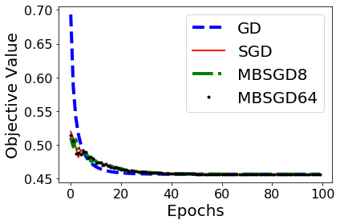

```python
# plot the 4 curves:
import matplotlib.pyplot as plt
%matplotlib inline

fig = plt.figure(figsize=(6, 4))

epochs_gd = range(len(objvals_gd))
epochs_sgd = range(len(objvals_sgd))
epochs_mbsgd8 = range(len(objvals_mbsgd8))
epochs_mbsgd64 = range(len(objvals_mbsgd64))

line0, = plt.plot(epochs_gd, objvals_gd, '--b', LineWidth=4)
line1, = plt.plot(epochs_sgd, objvals_sgd, '-r', LineWidth=2)
line2, = plt.plot(epochs_mbsgd8, objvals_mbsgd8, '-.g', LineWidth=4)
line3, = plt.plot(epochs_mbsgd64, objvals_mbsgd64, '.k', LineWidth=4)
plt.xlabel('Epochs', FontSize=20)
plt.ylabel('Objective Value', FontSize=20)
plt.xticks(FontSize=16)
plt.yticks(FontSize=16)
plt.legend([line0, line1, line2, line3], ['GD', 'SGD', 'MBSGD8', 'MBSGD64'], fontsize=20)
plt.tight_layout()
plt.show()
fig.savefig('compare_gd_sgd_mbsgd.pdf', format='pdf', dpi=1200)
```